# Classifying Airbnb Rentals with Logistic Regression

**Complete by: Tuesday 4 Mar. at class time**  
Data: https://jrladd.com/CIS241/data/nola_listings_2021.csv.gz

First, a reminder of the data and where it comes from:

> Airbnb was founded in 2008 to allow people to rent apartments, houses, and spaces directly to one another. The company provides an alternative to traditional hotels and rentals. Recently there's been a lot of public discussion about the effects Airbnb rentals have on neighborhoods: as Airbnb gets more popular, more and more homes and apartments that were previously used as private residences are now becoming full-time rentals. The data activists and journalists at [Inside Airbnb](http://insideairbnb.com/) are using public information about rentals to better understand these phenomena.

In the last workshop, you chose one independent variable (predictor) and explained its relationship to `price` (your dependent variable, or target) using bivariate linear regression. Now that you've gained a better understanding of the data, this week you'll **accurately predict whether Airbnbs in New Orleans are instantly bookable using logistic regression**.

As the [Data Dictionary from Inside Airbnb](http://insideairbnb.com/data-assumptions) says, the `instant_bookable` variable shows "whether the guest can automatically book the listing without the host requiring to accept their booking request." If a property is instantly bookable, that's usually an indicator that it's a commercial property rather than one individually owned. Being able to predict this category correctly aligns with Inside Airbnb's original mission of finding out how much commercial full-time rentals are edging out private residences.

You may need to try a few different models with some different sets of variables before you get one you feel confident in. You will also need to use multiple kinds of visualization for exploration, analysis, and validation.

This should be a polished and clearly-formatted report. Remember that in all of these steps **your interpretations are just as important as your code**. You should be taking time to interpret at each stage of your report, and make sure you are interpreting things *completely, accurately, and in terms of the data*.

## Ethical Considerations

How much should a temporary rental apartment cost? How many rentals should be available? If a city is a tourist destination, should more of its housing be devoted to temporary hotel-like rental space? Since the launch of Airbnb these questions have only gotten more pressing. Imagine you live in a popular neighborhood in a city that's a tourist destination. At first, you and your neighbors can make extra money by putting your homes and apartments up for rent on Airbnb when you're not using them. But over time, larger companies and individuals who *don't live in your neighborhood* start buying up homes solely to rent them on Airbnb full time. What might this do to your neighborhood?

The price and density of Airbnbs has effects not only on individuals who live in those neighborhoods and cities, but also on city officials, the real estate industry, and tourists themselves who may not be able to afford regular hotels and accommodations. How do you balance all of those competing concerns when pricing Airbnbs?

## Data Wrangling

- Import the data and prepare it for analysis. You will likely need to follow the same steps you took in the previous workshop (but you don't need to replicate the same errors—just skip right to the solutions).

## Exploratory Data Analysis

Let's learn a little more about this data set before moving on to modeling. **Write some code and/or some markdown to answer the following questions:**

- What are the different categories in the `room_type` column? What does room_type seem to be telling you?
- What do you think the `host_acceptance_rate` column is showing?
- How do the prices of Airbnb's differ across the two `instant_bookable` categories? Can you visualize this difference and talk about what you see? (Hint: a box plot would probably be best here, and you made need to limit some of your axes to make the plot readable.)
- What will be the predictor variables in your model? Assemble these variables into a list to use on the next step, and make sure you check for multicollinearity.

## Building Your Model

- Do you need to use reference coding this time? **If so, write some code to create dummy variables for your categorical predictors.**
- **Split your data into training and test sets.** How large should your test set be?
- **Create your model and fit it to the data.** You will need to set parameters for your model, but these will be a little different. Since we have a much larger dataset, let's use the `'sag'` solver, but keep penalty set to "none". You may get a warning that your model isn't "converging," which means that the coefficients aren't resolving to specific values as the model iterates. To fix this, you can change the `max_iter` parameter: the default is 100 iterations, but you will probably need it much higher than that.
- **Print the intercept and the coefficients, and interpret some of the coefficients.** If you're using a lot of predictor variables (say, more than 6 or 7), you don't need to interpret *all* of the coefficients. Instead, make sure that your reader understands which predictors seem to be influencing the model the most and the least.

## Prediction and Model Assessment

- **Create a variable to store the names of the two main *categories* we are predicting.**
- **Predict the probabilities for the test data, put them into a dataframe, and describe what you see.** Based on browsing this list, does it look like the model did a good job?
- **Predict the categories for the test data, and store this in a variable for the next steps.**
- **Visualize the confusion matrix for your model, and interpret the visualization.** Are there lots of false positives? false negatives? What could be going on here?
- **Calculate scores for accuracy, precision, and recall using the classification report. Explain how your model did based on these scores.**
- **Run at minimum a 5-fold cross-validation and interpret the results. Does your accuracy score hold up when your results are split differently?**
- **Visualize the ROC Curve, and report the AUC score for this curve. Explain how your model did based on these metrics.**
- **Write a brief conclusion summarizing how your model did and what you learned about the data. What would you recommend we try as a next step, to get better results?**

# Data Wrangling

Before analyzing and exploring our data, the following 3 libraries are imported:

```python
import pandas as pd # Data Analysis
import numpy as np # Numerical Calculations
import altair as alt # Data Visualizations
```

However, this workshop will use logistic regression, so more libraries need to be imported:

```python
from sklearn.linear_model import LogisticRegression # Logistic Regression
from sklearn.model_selection import train_test_split, cross_val_score # Allows models to be split into training and test data, as well as giving scores
from sklearn.metrics import RocCurveDisplay, confusion_matrix, classification_report # Imports ROC curves, confusion matrices, and classification reports
import matplotlib.pyplot as plt # matplotlib is used to visualize the ROC curve
```

Since the same dataset from airbnb1 is used, the following line of code assigns the airbnb DataFrame to a variable titled `airbnb`

```python
airbnb = pd.read_csv("https://jrladd.com/CIS241/data/nola_listings_2021.csv.gz")
```

In order to prevent errors from popping up when working with the `price` column, the block of code below is used to remove problematic characters (dollar sign, period, and comma) and convert the data type of the `price` column from an object to a float.

```python
airbnb = airbnb.assign(price = airbnb.price.str.replace("[\$\.\,]","",regex=True).astype(float)/100)
```

# Exploratory Data Analysis

In order to figure out all the different room types of airbnbs, the data type of the `room_type` column must be "category" so that it can display all of the categories of the `room_type` column.

```python
airbnb.room_type.astype("category")
```

```
0       Entire home/apt
1       Entire home/apt
2       Entire home/apt
3       Entire home/apt
4          Private room
             ...
6682    Entire home/apt
6683    Entire home/apt
6684    Entire home/apt
6685    Entire home/apt
6686    Entire home/apt
Name: room_type, Length: 6687, dtype: category
Categories (4, object): ['Entire home/apt', 'Hotel room', 'Private room', 'Shared room']
```

In this case, there are 4 different categories: Entire home/apt, Hotel room, Private room, and Shared room. Looking at the data, it seems that `room_type` is trying to convey that there is a variety of different types of accomomdations in the New Orleans area. These airbnb can accommodate large groups of visitors or individuals. For exmple, large groups can rent an entire home, whereas individuals may prefer a shared or private room. Also, New Orleans offers visitors' accommodations with a variety of price ranges. For example, an entire home may cost more than a shared room. Thus, as an individual, visiting New Orleans, one would still be able to find accommodations that fit his/her price range with a shared room and vice versa.

```python
airbnb.host_acceptance_rate
```

```
0        98%
1        83%
2        99%
3        97%
4        73%
        ...
6682     85%
6683     88%
6684     NaN
6685     75%
6686    100%
Name: host_acceptance_rate, Length: 6687, dtype: object
```

The `host_acceptance_rate` shows that there is a high host acceptance rate for airbnbs in New Orleans, ranging from 73 to 100 percent. However, there are some airbnbs with a low acceptance rate, going as low as 0%, meaning that the host rarely if at all accepts individuals to rent it.

```python
alt.data_transformers.enable("vegafusion")
```

```
DataTransformerRegistry.enable('vegafusion')
```

```python
alt.Chart(airbnb,title="Price of airbnbs depending on if they are instantly bookable or not").mark_boxplot(clip=True).encode(
    x=alt.X("instant_bookable:N",title="Instantly Bookable?"),
    y=alt.Y("price:Q",title="Price of airbnb (in dollars)").scale(domain=(0,2500))
)
```

[interactive chart not shown]

Based on the box plot, it appears that the prices of airbnbs are higher if they are instantly bookable as opposed to if the host is required to accept an individual's booking request (not instantly bookable).

```python
potential_predictors = ['price','room_type','has_availability', 'review_scores_rating', 'review_scores_accuracy', 'number_of_reviews', 'accommodates']
```

The first potential predictor I chose was `price` because as an airbnb host, the higher the price of a listing, the more likely a potential renter will be financially able to afford the property. Therefore, as a renter, the risk of losing money from a potnetial renter is low, as opposed to a lower priced airbnb rental, which could be potentially risky, meaning if a rental has a lower price point, the potential renters may not have the financial stability to afford the property and could potentially default on the payment. I chose `room_type` as a predictor for the same reasons as `price`, meaning the type of room correlates to its price, therefore, the higher the price, the better the room type and less financial risk to the host, and vice versa. As a host, it makes more sense to offer instantly bookable rooms to more expensive types of rooms and vice versa. I chose `has_availability` as a predictor because logically, there is no correlation between this and the `instant_bookable` variable. However, I was interested to see if my hypothesis had any validity. This was a case of choosing a random variable to see if it has any correlation to `instant_bookability`. I chose `review_scores_rating` because this is based on previous renters' thoughts about the property. The higher the review score, the more popular this particular property is. Due to its popularity, the property would gain more interest and it would be more difficult to constantly manually accept requests from potential rentors. Therefore, offering instant bookability would increase the number of rentals per year, earning more money for the airbnb host. I chose `review_scores_accuracy` for the same reason as `review_scores_rating`. I chose `number_of_reviews` as a potential predictor because the more reviews a property has, the more it has rented. This would lead one to believe that the more reviews, the more popular the property and more potential visitors in the future. For the same reason as `review_scores_rating`, the more times a property is rented, the more difficult it would be to manually approve requests Therefore, offering instant bookability would free up time and resources from the host and lead to a higher profitability. Lastly, I chose `accommodates` as a poential predictor for the same reason as `room_type`.

The best way to check for multicollinearity between two numerical predictor variables is to use a heatmap, as it shows the numerical correlation coefficients, giving more accurate data.

```python
airbnb_corr = airbnb[potential_predictors].corr(numeric_only=True).stack().reset_index().rename(columns={0:"corr","level_0":"var1","level_1":"var2"})

base = alt.Chart(airbnb_corr, title="Airbnb Correlation Matrix").mark_rect().encode(
    x=alt.X("var1:N",title=None),
    y=alt.Y("var2:N",title=None),
    color=alt.Color("corr",title="Correlation coefficient").scale(scheme='blueorange')
).properties(width=300,height=300)

text = base.mark_text(baseline='middle').encode(
    alt.Text('corr:Q',format=".2f"),
    color=alt.condition(
        (alt.datum.corr < -0.5) | (alt.datum.corr > 0.5),
        alt.value('white'),
        alt.value('black')
    )
)

base+text
```

[interactive chart not shown]

This heatmap shows the correlation coefficients between two of the 5 numerical predictor variables: including `accomodates`, `number_of_reviews`, `price`, `review_scores_accuracy`, and `review_scores_rating`. These variables were chosen due to their numerical nature. `has_availability` and `room_type` were not included in the heatmap because they are categorical and would therefore cause an error. Looking at the heatmap, it appears that `review_scores_accuracy` and `review_scores_rating` have the highest correlation coefficient, meaning they cause multicollinearity. Based on this high correlation coefficient, I chose to remove `review_scores_accuracy` as a potential predictor. My reason for doing this is because I believe that potential renters look at review score when booking a rental property and do not always take the time to read whether or not the reviews were accurate.

```python
target = "instant_bookable"
predictors = ['price', 'has_availability', 'review_scores_rating', 'number_of_reviews', 'accommodates']
```

## Building Your Model

Since I only chose two numerical predictor variables, I do not need to use reference coding again.

```python
predictors = ["price", "number_of_reviews"]
```

Since this is the same data from the previous workshop, my test size should also be the same, which means I will be using the same block of code:

```python
airbnb = airbnb.dropna(subset = predictors + [target])
X = pd.get_dummies(airbnb[predictors], drop_first=True)
y = airbnb[target]
```

```python
X = airbnb[predictors]
y = airbnb[target]
```

```python
X_train, X_test, y_train, y_test = train_test_split(
    X,
    y,
    test_size=1/3,
    random_state=42)
```

```python
max_iter = 10**100
```

```python
logit_model = LogisticRegression(penalty=None,
                                 solver='sag',
                                 random_state=42)
logit_model.fit(X_train, y_train)
```

```
LogisticRegression(penalty=None, random_state=42, solver='sag')
```

```python
print(f"Intercept: {logit_model.intercept_[0]:.3f}")
print("Coefficients:")
for name, coef in zip(X_train.columns, logit_model.coef_[0]):
    print(f"\t{name}: {coef:.4f}")
```

```
Intercept: 0.000
Coefficients:
	price: 0.0008
	number_of_reviews: 0.0005
```

# Prediction and Model Assessment

```python
# We can get prediction probabilities
probabilities = logit_model.predict_proba(X_test)
# We can get the predictions themselves
predictions = logit_model.predict(X_test)
# We can get the categories or classes we predicted
categories = logit_model.classes_
```

```python
# Let's make the probabilities look nicer
probabilities = pd.DataFrame(probabilities, columns=categories)
probabilities
```

|  | f | t |
| --- | --- | --- |
| 0 | 0.420885 | 0.579115 |
| 1 | 0.467217 | 0.532783 |
| 2 | 0.304525 | 0.695475 |
| 3 | 0.365528 | 0.634472 |
| 4 | 0.469910 | 0.530090 |
| ... | ... | ... |
| 2224 | 0.470725 | 0.529275 |
| 2225 | 0.466420 | 0.533580 |
| 2226 | 0.468578 | 0.531422 |
| 2227 | 0.451020 | 0.548980 |
| 2228 | 0.458682 | 0.541318 |

2229 rows × 2 columns

```python
# Calculate confusion matrix and transform data
conf_mat = confusion_matrix(y_test,predictions)
conf_mat = pd.DataFrame(conf_mat,index=categories,columns=categories)
conf_mat = conf_mat.melt(ignore_index=False).reset_index()
# Create heatmap
heatmap = alt.Chart(conf_mat).mark_rect().encode(
    x=alt.X("variable:N").title("Predicted Response"),
    y=alt.Y("index:N").title("True Response"),
    color=alt.Color("value:Q", legend=None).scale(scheme="blues")
).properties(
    width=400,
    height=400
)
# Add text labels for numbers
text = heatmap.mark_text(baseline="middle").encode(
    text=alt.Text("value:Q"),
    color=alt.value("black"),
    size=alt.value(50)
)

heatmap + text
```

[interactive chart not shown]

```python
print(classification_report(y_test, predictions, zero_division=0))
```

```
              precision    recall  f1-score   support

           f       0.00      0.00      0.00       986
           t       0.56      1.00      0.72      1243

    accuracy                           0.56      2229
   macro avg       0.28      0.50      0.36      2229
weighted avg       0.31      0.56      0.40      2229
```

```python
scores = cross_val_score(logit_model, X, y, cv=5)
print(f"{scores.mean():.2} accuracy with standard deviation {scores.std():.2}")
```

```
0.55 accuracy with standard deviation 0.028
```

Even after differently splitting the model 5 times, the accuracy score remains the same. The standard deviation is around 0.028, meaning that the model's performance is consistent with our data. Therefore, our model's predictions are unreliable and cannot be trusted.

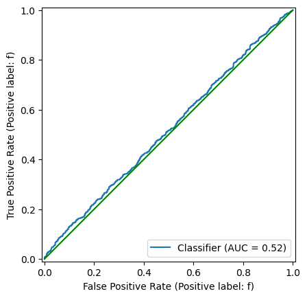

```python
# Create our ROC Curve plot
RocCurveDisplay.from_predictions(y_test,
                                 probabilities[categories[0]],
                                 pos_label=categories[0])

# Draw a green line for 0
plt.plot([0, 1], [0, 1], color = 'g')
```

The AUC score for this curve is 0.52. An AUC score of 0.7 or higher is considered acceptable. However, based on these metrics, the model is unacceptable and further validates my conclusion that the model is unreliable and cannot be trusted. In fact, it almost appears as if the model randomly guesses if an airbnb is instantly bookable or not.

In summary, my model performed poorly. Although I had high hopes, my variables were not good predictors of determining the probability of an airbnb being instantly bookable or not. Based on my research, `price` and `number_of_reviews` are not good indicators of whether or not an airbnb is instantly bookable. As a next step, I would add more predictors. However, this would mean that I would need to run a large number of models due to the fact that adding too many variables to a model results in the coefficients not "converging". This would mean that trying to determine which variables predict an airbnb's probability of being instantly bookable would be long and tedious. If you are willing to put in the time and effort, eventually, one would determine which variables are the best predictors of airbnb's instant bookability.